# PeerAccessment

Sunday, April 12, 2015

# This is the reproducible research accessment

Loading and preprocessing the data

Show any code that is needed to

Load the data (i.e. read.csv())

Process/transform the data (if necessary) into a format suitable for your analysis

```r
if(!file.exists("activity.zip"))
{
stop("File Not Found")
}
unzip("activity.zip",junkpath=TRUE)

rs<-read.csv("activity.csv",colClasses=c("numeric","character","numeric"))
library(dplyr)
library(lattice)
rs$date <- as.Date(rs$date, "%Y-%m-%d")
```

What is mean total number of steps taken per day?

For this part of the assignment, you can ignore the missing values in the dataset.

Calculate the total number of steps taken per day

If you do not understand the difference between a histogram and a barplot, research the difference between them. Make a histogram of the total number of steps taken each day

Calculate and report the mean and median of the total number of steps taken per day

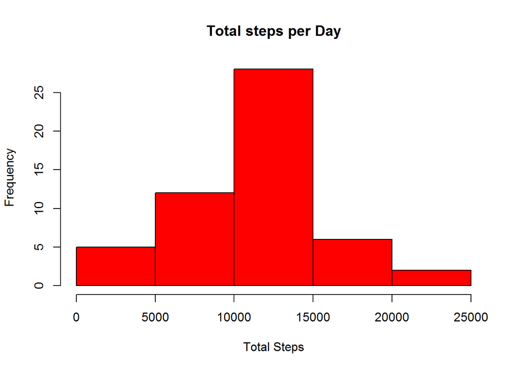

```
Summary the result to get the median and mean
```

```r
    rs1<-group_by(rs,date)
    rs2<-summarise(rs1,total=sum(steps))
    hist(rs2$total,col="Red",main="Total steps per Day",xlab="Total Steps")
```

```r
    summary(rs2)
```

```
##       date                total
##  Min.   :2012-10-01   Min.   :   41
##  1st Qu.:2012-10-16   1st Qu.: 8841
##  Median :2012-10-31   Median :10765
##  Mean   :2012-10-31   Mean   :10766
##  3rd Qu.:2012-11-15   3rd Qu.:13294
##  Max.   :2012-11-30   Max.   :21194
##                       NA's   :8
```

What is the average daily activity pattern?

Make a time series plot (i.e. type = “l”) of the 5-minute interval (x-axis) and the average number of steps taken, averaged across all days (y-axis)

Which 5-minute interval, on average across all the days in the dataset, contains the maximum number of steps?

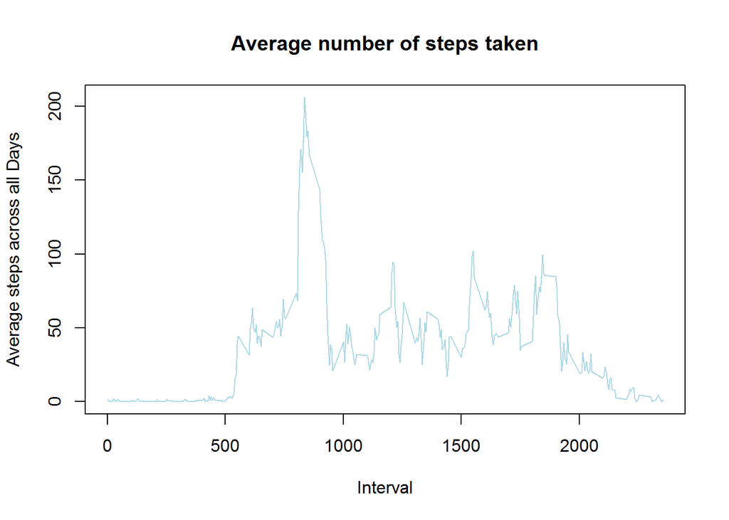

```r
time_series<-tapply(rs$steps,rs$interval,mean,na.rm=TRUE)
plot(row.names(time_series),time_series,type="l",xlab="Interval",ylab="Average steps across all Days",main="Average number of steps taken",col="lightblue")
```

```r
max<-which.max(time_series)
names(max)
```

```
## [1] "835"
```

## Inputing missing values

Calculate and report the total number of missing values in the dataset (i.e. the total number of rows with NAs)

```r
rs4 <- sum(is.na(rs))
rs4
```

```
## [1] 2304
```

Devise a strategy for filling in all of the missing values in the dataset. The strategy does not need to be sophisticated. For example, you could use the mean/median for that day, or the mean for that 5-minute interval,etc

Fist Na replaced by mean in 5 min interval

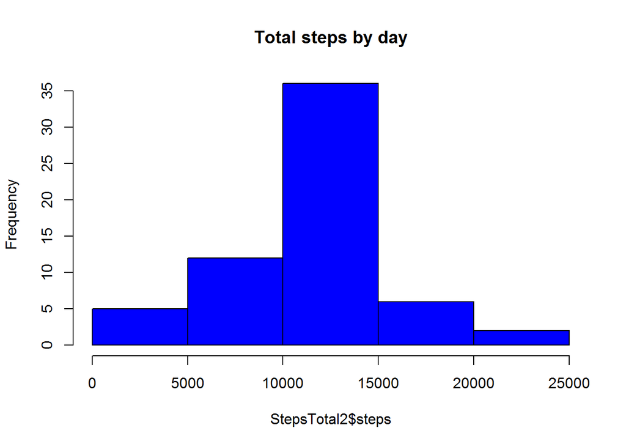

```r
StepsAverage <- aggregate(steps ~ interval, data = rs, FUN = mean)
fillNA <- numeric()
for (i in 1:nrow(rs)) {
    obs <- rs[i, ]
    if (is.na(obs$steps)) {
        steps <- subset(StepsAverage, interval == obs$interval)$steps
    } else {
        steps <- obs$steps
    }
    fillNA <- c(fillNA, steps)
}
rs5<-rs
rs5$steps<-fillNA
StepsTotal2 <- aggregate(steps ~ date, data = rs5, sum, na.rm = TRUE)
hist(StepsTotal2$steps,main="Total steps by day",slab="day",col="blue")
```

```r
mean(StepsTotal2$steps)
```

```
## [1] 10766.19
```

```r
median(StepsTotal2$steps)
```

```
## [1] 10766.19
```

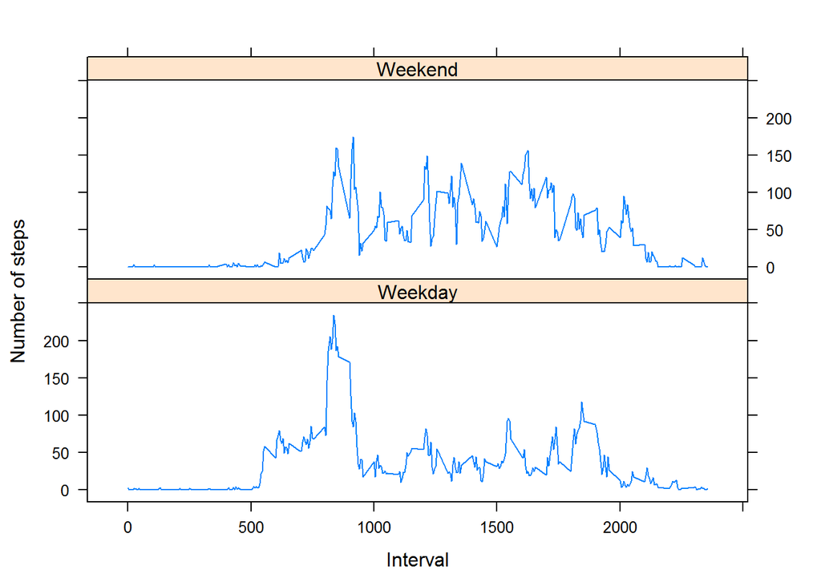

```r
day <- weekdays(rs$date)
daylevel <- vector()
for (i in 1:nrow(rs)) {
    if (day[i] == "星期六" | day[i]=="Saturday") {
        daylevel[i] <- "Weekend"
    } else if (day[i] == "Sunday" | day[i]=="星期日") {
        daylevel[i] <- "Weekend"
    } else {
        daylevel[i] <- "Weekday"
    }
}
rs$daylevel <- daylevel
rs$daylevel <- factor(rs$daylevel)

stepsByDay <- aggregate(steps ~ interval + daylevel, data = rs, mean)
names(stepsByDay) <- c("interval", "daylevel", "steps")
xyplot(steps ~ interval | daylevel, stepsByDay, type = "l", layout = c(1, 2),
    xlab = "Interval", ylab = "Number of steps")
```